# Identifying Red Kite feeding sites from tracking data

Steffen Oppel

# Background

The Red Kite is a widespread raptor in Switzerland that benefits from anthropogenic food supplementation. To better understand the spatial extent of anthropogenic food provisioning we are using the tracking data of Red Kites to identify places where the tracked behaviour of kites is consistent with the recorded behaviour of tracked kites at known anthropogenic feeding sites. This work is based on the MSc thesis of Nathalie Heiniger (2020).

# Data preparation

The data we are using are hourly red kite tracking data from 2016 - 2022, which we first filter to the extent of Switzerland to remove locations during migration and in winter, resulting in 949489 GPS locations. The tracking locations are converted into tracks and metrics such as step length, speed, and turning angle are calculated for each step (between two subsequent GPS locations) to extract information on the behaviour of the bird, as presence at a feeding site would typically involve slow speeds, short step lengths and high turning angles. The tracking data are then spatially intersected with land cover data, specifically to remove locations in forests (where birds nest, but where anthropogenic feeding is unlikely), and select locations near human settlements. All locations within 2810 forest fragments are removed, and only locations within 50 m of 4976 buildings larger than 65 sqm are retained. In addition, the location of 6459 anthropogenic feeding stations are known (which includes all experimental feeding instances), and GPS locations within 50 m of these feeding stations are used to train a model to detect feeding stations. As a result of the various steps, we have a total of 149520 GPS locations and 3468 of these locations near a known anthropogenic feeding station (including temporal overlap for all experimental feeding stations for which the time of food provisioning was available).

# Approach to analysis

Anthropogenic feeding stations attract Red Kites regularly, and there will therefore be data patterns at multiple hierarchical levels that could indicate the presence of an anthropogenic feeding site. At the individual level, locations with low speed, high turning angles, and high and consistent revisitation rates over the whole season should be indicative of a feeding place. However, such locations may occur in many places and be indicative of both natural and artificial foraging areas. Thus, the accumulation of several individuals in one place over the season is an additional criterion to consider.

We therefore proceed in two steps, in the first step we use the filtered tracking data in a random forest model to predict whether locations occurred within a known anthropogenic feeding area or not. This model will rely on 19 variables and be tuned for high sensitivity, given that the knowledge of anthropogenic feeding areas is not exhaustive, and birds may behave similarly in areas without anthropogenic feeding.

The locations predicted to be near anthropogenic feeding stations by this model are then aggregated in 500 m grid cells to summarise visitation patterns at the population level. We calculate the number and proportion of predicted ‘feeding’ locations over the total number of GPS locations in a grid cell, and also calculate the number and proportion of predicted ‘feeding’ individuals over the total number of individuals occurring in each grid cell. This summary information is then used in a second random forest model, which uses the number and proportion of locations per grid cell to predict whether an anthropogenic feeding station was present in that grid cell. This model is based on 1576 grid cells with sufficient data (at least 10 Red Kite GPS locations), of which 173 contained anthropogenic feeding stations.

# Preliminary results

The hourly tracking data were randomly split into 100177 locations for training the first random forest model, and 49343 locations for validation, and the sensitivities reported here are on test data not used to train the model.

The random forest model classified 1101 of 1145 known presences at anthropogenic feeding stations correctly (96.2 %), but also predicted that 2467 of 48198 other GPS locations (but not within 50 m of a known feeding station) were consistent with criteria that could indicate that Red Kites were feeding there. The variables that contributed the most to classifying GPS locations as near a feeding station are shown in this graph:

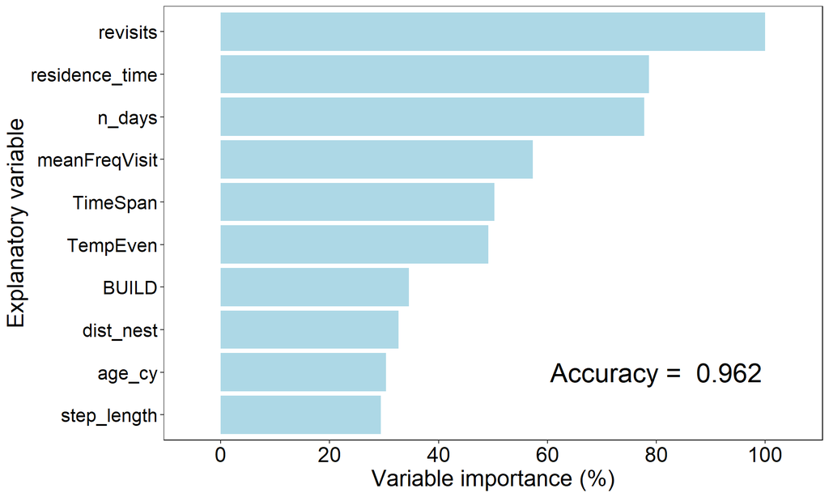

*Fig. 1: Relative variable importance to predict whether GPS locations are associated with anthropogenic feeding sites*

There were 8842 locations of 484 bird-seasons predicted by the random forest algorithm to be consistent with foraging at anthropogenic feeding stations. These locations were then summarised in 500 m grid cells, resulting in 1576 of the 4047 grid cells in the study area where predicted ‘anthropogenic feeding locations’ occurred. These locations were then summarised by grid cell, leading to a range of proportions from 0% to 100% of GPS locations and 0 to 61.5% of individuals that were predicted to be ‘feeding’ in a grid cell.

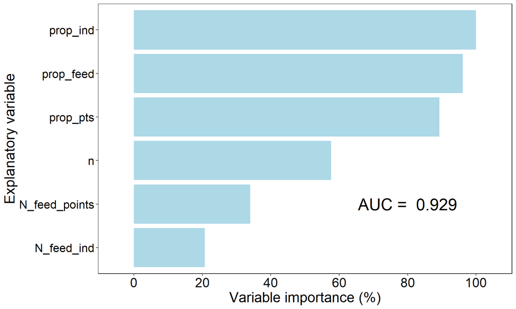

*Fig. 2: Relative variable importance to predict whether anthropogenic feeding sites exist in grid cells*

[interactive chart not shown]

*Fig. 3: Map of existing (green dots) and predicted probability of the presence of anthropogenic feeding sites in Switzerland (so far only in study area)*

# Next steps

We have requested remote sensing data from across Switzerland to potentially predict anthropogenic feeding sites across the country. This would allow us to extrapolate the extent of anthropogenic feeding that occurs (as far as we can tell from our tracked sample of birds).

We can now quantify the proportion of daytime that Red Kites spend in grid cells with a high predicted probability of containing an anthropogenic feeding site as a proxy for their ‘sociality’ or ‘dependence’, and relate that proxy to survival, residence, and breeding success.